# Regression model

DAI,WEIFAN

### Model Inference, assumption and ANOVA

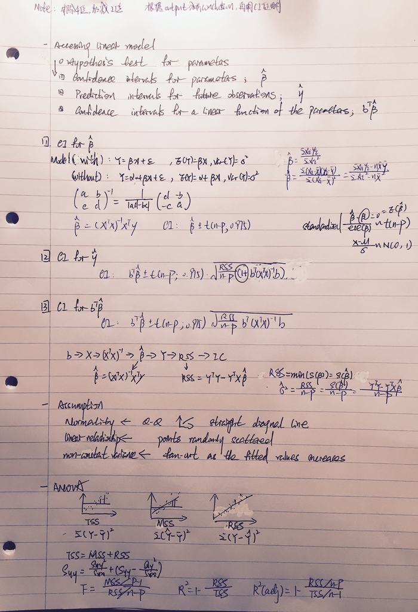

### ACNOVA–Factors and Interaction

- **three models**
1. Seperate lines `lm(Y~G*X)` $E(Y_{ij}=\alpha_i+\beta_j(x_{ij}-\bar{x_{i.}}))$
2. Parallel lines `lm(Y~G+X)` $E(Y_{ij}=\alpha_i+\beta(x_{ij}-\bar{x_{i.}}))$
3. Singel lines `lm(Y~X)` $E(Y_{ij}=\alpha+\beta(x_{ij}-\bar{x_{..}}))$
- **comparing models**:
1. acova
2. check CI for $\beta_1-\beta_2$
- **an example**
  - Question of Interest: Are there any differences between the cholesterol measurements in Iowa and those in Nebraska?
  - Exploratory Analysis:
  1. anove

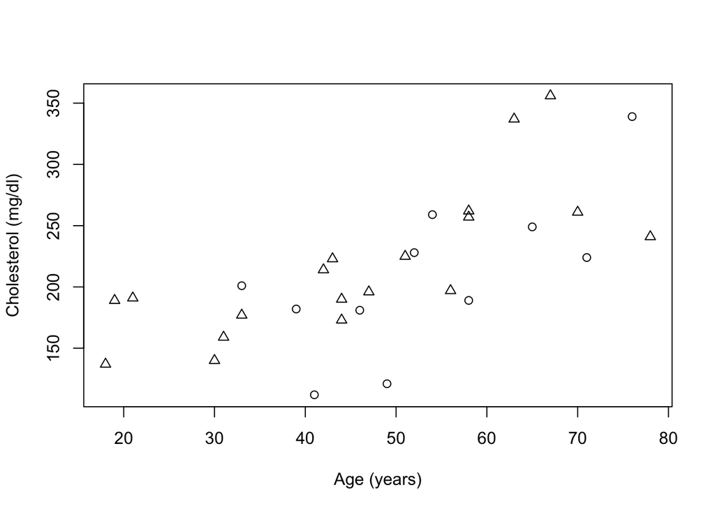

```r
# Produce a plot of cholesterol against age, labelled by state using the commands:
plot(Cholesterol~Age, pch=State, data=cholest,
ylab="Cholesterol (mg/dl)", xlab="Age (years)")
```

```r
# The argument locator(n=1) allows you to select where you would like the legend to be placed on the plot, hover the icon over the plot at the point where you wish to place the legend and then click on the plot.
# What do you conclude from the plot?
# Do you think that the relationship between cholesterol and age is completely different in each state?
# Do you think either a parallel or single line relationship may be appropriate?
```

- **Comments:**
  1. Cholesterol increases as age increases.
  2. It is difficult to tell whether or not the relationship between cholesterol and age differs for each state.
  3. There is a slight suggestion that the Nebraska values lie slightly higher but it maybe that a single regression line is appropriate.

```r
Model1 <- lm(Cholesterol~Age*statename, data=as.data.frame(cholest))

#This fits a linear regression model between cholesterol and age where the relationship is allowed to change depending on state. Therefore, the model contains a covariate of age, a factor of state name and the interaction between state name and age. If the model with two completely separate regression lines is appropriate then we say that there is an interaction (and the interaction term would be statistically significant). An interaction would tell us that the relationship between cholesterol and age is different depending on whether the population of interest is Iowa or Nebraska.

#In order to assess this, the output of most interest to us here is in the analysis of variance table obtained using:

anova(Model1)
```

```
## Analysis of Variance Table
##
## Response: Cholesterol
##               Df Sum Sq Mean Sq F value    Pr(>F)
## Age            1  48976   48976 26.3124 2.388e-05 ***
## statename      1   5456    5456  2.9315   0.09877 .
## Age:statename  1    709     709  0.3809   0.54247
## Residuals     26  48395    1861
## ---
## Signif. codes:  0 '***' 0.001 '**' 0.01 '*' 0.05 '.' 0.1 ' ' 1
```

- **Comments:** The interaction term is Age:statename. Since the p-value for this term is > 0.05 we reject the model with completely separate regression lines and conclude that a model with a single slope i.e. a line with parallel regression lines should be fitted and investigated.

```r
#Since the interaction term is not statistically significant we then fit a model which
#assumes parallel lines:

Model2 <- lm(Cholesterol~Age+statename, data=as.data.frame(cholest))
anova(Model2)
```

```
## Analysis of Variance Table
##
## Response: Cholesterol
##           Df Sum Sq Mean Sq F value    Pr(>F)
## Age        1  48976   48976 26.9298 1.831e-05 ***
## statename  1   5456    5456  3.0003   0.09466 .
## Residuals 27  49104    1819
## ---
## Signif. codes:  0 '***' 0.001 '**' 0.01 '*' 0.05 '.' 0.1 ' ' 1
```

- **Comments:** Since the p-value for the group/factor term (statename) is not statistically significant (0.095) a single regression line might be appropriate for the data.

```r
# To fit a single regression line:
Model3 <- lm(Cholesterol~Age, data=as.data.frame(cholest))
anova(Model3)
```

```
## Analysis of Variance Table
##
## Response: Cholesterol
##           Df Sum Sq Mean Sq F value    Pr(>F)
## Age        1  48976   48976  25.134 2.673e-05 ***
## Residuals 28  54560    1949
## ---
## Signif. codes:  0 '***' 0.001 '**' 0.01 '*' 0.05 '.' 0.1 ' ' 1
```

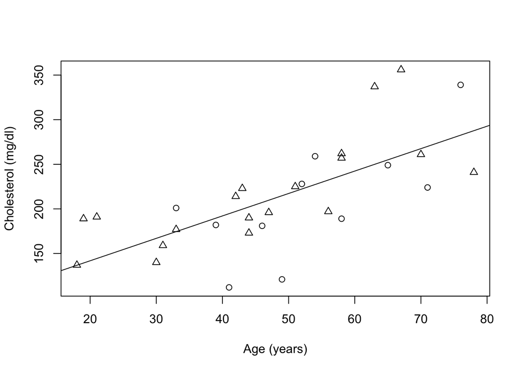

```r
# The final model can be plotted on the data in Figure 2.
plot(Cholesterol~Age, pch=State, data=cholest,
ylab="Cholesterol (mg/dl)", xlab="Age (years)")
abline(Model3)
```

- **Comments:** The above analysis could also have been performed by computing confidence intervals to investigate differences between the regression lines.
  2. Confidence Intervals
  - Confidence intervals can also be used to compare the models. To compare the full model with completely separate lines and the parallel lines model, compute a CI to compare the slopes.
  - The 95% CI for $\beta_1-\beta_2$ is $(-1.67, 3.11)$ **Conclusion:** Since the confidence interval includes zero the is insufficient evidence of a difference between the two slopes. Therfore, a model with a single slope i.e. the parallel lines model may be appropriate.
  - The 95% confidence interval for the difference between the parallel regression lines and a single regression line, $\alpha_1-\alpha_2+\beta(\bar(x_{2.})-\bar(x_{1.}))$ is: $(-57.35, 5.266)$ **Conclusion:** Again, since this interval contains zero we have the same result as indicated by the p-values above. There is insufficient evidence of a difference between the lines and hence a single regression line to describe the relationship between cholesterol and age may be appropriate.